# ch08_03C_cancer_lightGBM_model

### 위스콘신 유방암 데이터 셋 - LightGBM 모델 구현

### 학습 목표

- LightGBM 모델을 이용하여 학습과 예측을 수행해 본다.
- 예측을 수행한 결과에 대해 평가를 수행해 본다.

### 학습 내용

- LightGBM 모델 만들기 - 위스콘신 유방암 데이터 셋
- 평가해보기

### 데이터 로드 및 전처리

```python
import pandas as pd
from sklearn.datasets import load_breast_cancer
import matplotlib.pyplot as plt
import matplotlib

from lightgbm import LGBMClassifier
from sklearn.model_selection import train_test_split
```

```python
cancer = load_breast_cancer()

cancer_df = pd.DataFrame(cancer.data, columns=cancer.feature_names)
cancer_df.head()
```

|  | mean radius | mean texture | mean perimeter | mean area | mean smoothness | mean compactness | mean concavity | mean concave points | mean symmetry | mean fractal dimension | ... | worst radius | worst texture | worst perimeter | worst area | worst smoothness | worst compactness | worst concavity | worst concave points | worst symmetry | worst fractal dimension |
| --- | --- | --- | --- | --- | --- | --- | --- | --- | --- | --- | --- | --- | --- | --- | --- | --- | --- | --- | --- | --- | --- |
| 0 | 17.99 | 10.38 | 122.80 | 1001.0 | 0.11840 | 0.27760 | 0.3001 | 0.14710 | 0.2419 | 0.07871 | ... | 25.38 | 17.33 | 184.60 | 2019.0 | 0.1622 | 0.6656 | 0.7119 | 0.2654 | 0.4601 | 0.11890 |
| 1 | 20.57 | 17.77 | 132.90 | 1326.0 | 0.08474 | 0.07864 | 0.0869 | 0.07017 | 0.1812 | 0.05667 | ... | 24.99 | 23.41 | 158.80 | 1956.0 | 0.1238 | 0.1866 | 0.2416 | 0.1860 | 0.2750 | 0.08902 |
| 2 | 19.69 | 21.25 | 130.00 | 1203.0 | 0.10960 | 0.15990 | 0.1974 | 0.12790 | 0.2069 | 0.05999 | ... | 23.57 | 25.53 | 152.50 | 1709.0 | 0.1444 | 0.4245 | 0.4504 | 0.2430 | 0.3613 | 0.08758 |
| 3 | 11.42 | 20.38 | 77.58 | 386.1 | 0.14250 | 0.28390 | 0.2414 | 0.10520 | 0.2597 | 0.09744 | ... | 14.91 | 26.50 | 98.87 | 567.7 | 0.2098 | 0.8663 | 0.6869 | 0.2575 | 0.6638 | 0.17300 |
| 4 | 20.29 | 14.34 | 135.10 | 1297.0 | 0.10030 | 0.13280 | 0.1980 | 0.10430 | 0.1809 | 0.05883 | ... | 22.54 | 16.67 | 152.20 | 1575.0 | 0.1374 | 0.2050 | 0.4000 | 0.1625 | 0.2364 | 0.07678 |

5 rows × 30 columns

```python
print( cancer_df.shape)
```

```
(569, 30)
```

### 데이터 설명

- 위스콘신 유방암 데이터 세트는 유방암의 악성 종양, 양성 종양 여부를 결정하는 이진 분류
- 종양의 크기, 모양 등의 형태와 관련한 많은 피처를 가지고 있음.
- 569개의 행과, 30개의 피처로 이루어진 데이터
- null 값이 없음. 값들은 실수로 되어 있음.

### 데이터 나누기

```python
# 피처와 레이블를 지정.
X = cancer_df[:]
y = cancer.target

X.shape, y.shape
```

```
((569, 30), (569,))
```

```python
X_train , X_test, y_train, y_test = train_test_split(X, y,
                                                     test_size=0.2, random_state=0)

X_train.shape, X_test.shape, y_train.shape, y_test.shape
```

```
((455, 30), (114, 30), (455,), (114,))
```

### 02 LightGBM

- LightGBM은 XGBoost와 부스팅 계열 알고리즘에서 가장 각광을 받고 있음.
- LightGBM은 가장 큰 장점은 XGBoost보다 학습에 걸리는 시간이 훨씬 적다. 메모리 사용량도 적다.
- LightGBM과 XGBoost의 예측 성능은 별다른 차이가 없음.
- LightGBM이 XGBoost보다 2년 후에 만들어짐.
- [단점] 적은 데이터 셋일 경우, 과적합이 발생할 가능성이 있음. (문서상에는 10000건 이하의 데이터로 기술하고 있음.)
- lightgbm 설치
  - pip install lightgbm

#### LightGBM의 파이썬 패키지인 lightgbm에서 LGBMClassifier 불러오기

```python
from lightgbm import LGBMClassifier
```

```python
# 모델 선택
model_lgbm = LGBMClassifier(n_estimators= 400)

# Lgbm은 중간에 조기 중단이 가능.
evals = [(X_test, y_test)]

model_lgbm.fit(X_train, y_train, early_stopping_rounds=100,
               eval_metric='logloss',
               eval_set=evals,
               verbose=True)

preds = model_lgbm.predict(X_test)
pred_proba = model_lgbm.predict_proba(X_test)[:, 1]
```

```
[1]	valid_0's binary_logloss: 0.602575
[2]	valid_0's binary_logloss: 0.536123
[3]	valid_0's binary_logloss: 0.482224
[4]	valid_0's binary_logloss: 0.439121
[5]	valid_0's binary_logloss: 0.399484
[6]	valid_0's binary_logloss: 0.360741
[7]	valid_0's binary_logloss: 0.329635
[8]	valid_0's binary_logloss: 0.300259
[9]	valid_0's binary_logloss: 0.279599
[10]	valid_0's binary_logloss: 0.259173
[11]	valid_0's binary_logloss: 0.239127
[12]	valid_0's binary_logloss: 0.222309
[13]	valid_0's binary_logloss: 0.209351
[14]	valid_0's binary_logloss: 0.194316
[15]	valid_0's binary_logloss: 0.185282
[16]	valid_0's binary_logloss: 0.173675
[17]	valid_0's binary_logloss: 0.165308
[18]	valid_0's binary_logloss: 0.155769
[19]	valid_0's binary_logloss: 0.14865
[20]	valid_0's binary_logloss: 0.140995
[21]	valid_0's binary_logloss: 0.134334
[22]	valid_0's binary_logloss: 0.126574
[23]	valid_0's binary_logloss: 0.119264
[24]	valid_0's binary_logloss: 0.114799
[25]	valid_0's binary_logloss: 0.110568
[26]	valid_0's binary_logloss: 0.106157
[27]	valid_0's binary_logloss: 0.100816
[28]	valid_0's binary_logloss: 0.0978631
[29]	valid_0's binary_logloss: 0.0945873
[30]	valid_0's binary_logloss: 0.0916942
[31]	valid_0's binary_logloss: 0.0863612
[32]	valid_0's binary_logloss: 0.0822965
[33]	valid_0's binary_logloss: 0.078824
[34]	valid_0's binary_logloss: 0.0752847
[35]	valid_0's binary_logloss: 0.0718233
[36]	valid_0's binary_logloss: 0.0696371
[37]	valid_0's binary_logloss: 0.0676798
[38]	valid_0's binary_logloss: 0.0665177
[39]	valid_0's binary_logloss: 0.0660656
[40]	valid_0's binary_logloss: 0.064516
```

[output cut: 97 more lines]

```
[138]	valid_0's binary_logloss: 0.0624083
[139]	valid_0's binary_logloss: 0.0640835
[140]	valid_0's binary_logloss: 0.0648152
[141]	valid_0's binary_logloss: 0.0651628
[142]	valid_0's binary_logloss: 0.0648746
[143]	valid_0's binary_logloss: 0.0631569
[144]	valid_0's binary_logloss: 0.0645178
[145]	valid_0's binary_logloss: 0.0649077
[146]	valid_0's binary_logloss: 0.0653192
[147]	valid_0's binary_logloss: 0.0644097
[148]	valid_0's binary_logloss: 0.0630949
[149]	valid_0's binary_logloss: 0.0634037
[150]	valid_0's binary_logloss: 0.0638329
[151]	valid_0's binary_logloss: 0.0636558
[152]	valid_0's binary_logloss: 0.0632649
```

- 조기 중단으로 400번까지 수행하지 않고, 중간에 중단함.

```python
from sklearn import metrics
```

```python
# 모델 평가를 위한 함수 설정
def get_clf_eval(y_test, y_pred=None, pred_proba=None):
  confusion = metrics.confusion_matrix(y_test, y_pred)
  accuracy = metrics.accuracy_score(y_test, y_pred)
  precision = metrics.precision_score(y_test, y_pred)
  recall = metrics.recall_score(y_test, y_pred)
  F1_score = metrics.f1_score(y_test, y_pred)

  AUC = metrics.roc_auc_score(y_test, pred_proba)

  # 평가지표 출력
  print('오차행렬:\n', confusion)
  print('\n정확도: {:.4f}'.format(accuracy))
  print('정밀도: {:.4f}'.format(precision))
  print('재현율: {:.4f}'.format(recall))
  print('F1: {:.4f}'.format(F1_score))
  print('AUC: {:.4f}'.format(AUC))
```

```python
get_clf_eval(y_test, preds, pred_proba)
```

```
오차행렬:
 [[44  3]
 [ 1 66]]

정확도: 0.9649
정밀도: 0.9565
재현율: 0.9851
F1: 0.9706
AUC: 0.9990
```

### 피처 중요도 시각화

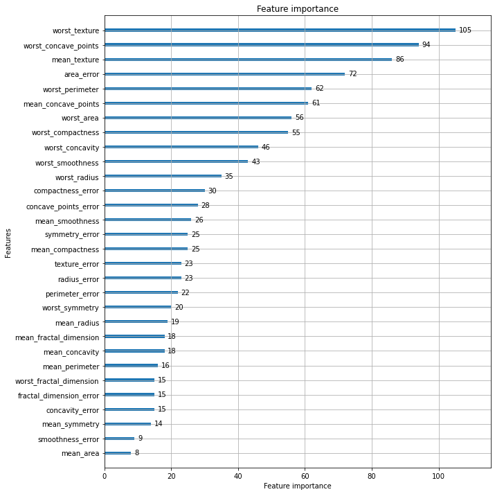

```python
from lightgbm import plot_importance
import matplotlib.pyplot as plt

fig, ax = plt.subplots(figsize=(10,12))
plot_importance(model_lgbm, ax=ax)
```

### 정리

- lightGBM은 가장 많이 쓰이는 빠르고 성능 좋은 머신러닝 알고리즘 중의 하나이다.